# PP1

Rebecca Smith

2/17/2021

##Load and Install Libraries

```r
library(tidyverse)
library(haven)
ATP_W53 <- read_sav("~/DataScience/Portfolio/W53_Sep19/W53_Sep19/ATP W53.sav")
```

For this portfolio piece, I will be using a dataset from the Pew Research Center. In September 2019, Pew conducted their American Trends Panel Wave 53. This survey contained questions regarding policy and social preferences, attitudes and opinions towards politicians and the parties, among other topics.

In the survey, they ask respondents to indicate how much of a problem certain social and policy issues are in America. These questions and responses will be the focus of this project.

To begin, let’s take a look at the dataset in its entirety.

```r
View(ATP_W53)
str(ATP_W53)
```

```
## tibble [9,895 x 183] (S3: tbl_df/tbl/data.frame)
##  $ QKEY              : num [1:9895] 1e+05 1e+05 1e+05 1e+05 1e+05 ...
##   ..- attr(*, "label")= chr "Unique ID USE THIS TO MERGE WAVES"
##   ..- attr(*, "format.spss")= chr "F8.0"
##   ..- attr(*, "display_width")= int 11
##  $ LANG_W53          : dbl+lbl [1:9895] 1, 1, 1, 1, 1, 1, 1, 1, 1, 1, 1, 1, 1, 1, 1, 1, 1, 1,...
##    ..@ label      : chr "Language of survey materials"
##    ..@ format.spss: chr "F8.0"
##    ..@ labels     : Named num [1:2] 1 2
##    .. ..- attr(*, "names")= chr [1:2] "English" "Spanish"
##  $ DEVICE_TYPE_W53   : dbl+lbl [1:9895] 2, 2, 1, 1, 3, 1, 3, 3, 3, 1, 1, 3, 3, 1, 1, 1, 1, 3,...
##    ..@ label        : chr "W53 Device Type"
##    ..@ format.spss  : chr "F4.0"
##    ..@ display_width: int 21
##    ..@ labels       : Named num [1:5] 1 2 3 4 5
##    .. ..- attr(*, "names")= chr [1:5] "Mobile phone" "Tablet" "Desktop" "Phone (CATI)" ...
##  $ FORM_W53          : dbl+lbl [1:9895] 2, 3, 4, 1, 2, 3, 4, 1, 2, 3, 4, 1, 2, 3, 4, 1, 3, 2,...
##    ..@ label        : chr "Wave 53 Form value"
##    ..@ format.spss  : chr "F4.0"
##    ..@ display_width: int 15
##    ..@ labels       : Named num [1:4] 1 2 3 4
##    .. ..- attr(*, "names")= chr [1:4] "Form 1" "Form 2" "Form 3" "Form 4"
##  $ POL1DT_W53        : dbl+lbl [1:9895] 2, 1, 1, 1, 2, 2, 1, 1, 2, 1, 2, 1, 2, 1, 1, 2, 2, 2,...
##    ..@ label        : chr "POL1DT.  Do you approve or disapprove of the way Donald Trump is handling his job as president?"
##    ..@ format.spss  : chr "F12.0"
##    ..@ display_width: int 5
##    ..@ labels       : Named num [1:3] 1 2 99
##    .. ..- attr(*, "names")= chr [1:3] "Approve" "Disapprove" "Refused"
##  $ POL1DTSTR_W53     : dbl+lbl [1:9895] 1, 1, 1, 2, 1, 1, 2, 1, 1, 1, 1, 1, 1, 2, 1, 1, 2, 1,...
##    ..@ label        : chr "POL1DTSTR.  Do you approve/disapprove of the way Donald Trump is handling his job as president…."
##    ..@ format.spss  : chr "F12.0"
##    ..@ display_width: int 5
##    ..@ labels       : Named num [1:3] 1 2 99
##    .. ..- attr(*, "names")= chr [1:3] "Very strongly" "Not so strongly" "Refused"
##  $ FUTGEN_W53        : dbl+lbl [1:9895] NA,  1, NA,  2, NA,  2, NA,  2, NA,  1, NA,  2, NA,  ...
##    ..@ label        : chr "FUTGEN.  Do you think life for future generations of Americans will be…"
##    ..@ format.spss  : chr "F12.0"
##    ..@ display_width: int 5
##    ..@ labels       : Named num [1:4] 1 2 3 99
##    .. ..- attr(*, "names")= chr [1:4] "Better than life today" "Worse than life today" "About the same as life today" "Refused"
```

[output cut: 538 more lines]

```
##    ..@ labels       : Named num [1:5] 1 2 3 4 99
##    .. ..- attr(*, "names")= chr [1:5] "Very well" "Somewhat well" "Not too well" "Not at all well" ...
##  $ DEMPTYTRAIT_c_W53 : dbl+lbl [1:9895] NA,  4,  4, NA, NA,  2,  2, NA, NA,  4,  2, NA, NA,  ...
##    ..@ label        : chr "DEMPTYTRAIT_c. How well do each of the following phrases describe the Democratic Party?  Cares about the middle class"
##    ..@ format.spss  : chr "F12.0"
##    ..@ display_width: int 5
##    ..@ labels       : Named num [1:5] 1 2 3 4 99
##    .. ..- attr(*, "names")= chr [1:5] "Very well" "Somewhat well" "Not too well" "Not at all well" ...
##  $ DEMPTYTRAIT_d_W53 : dbl+lbl [1:9895] NA,  4,  4, NA, NA,  2,  3, NA, NA,  4,  2, NA, NA,  ...
##    ..@ label        : chr "DEMPTYTRAIT_d. How well do each of the following phrases describe the Democratic Party?  Represents the interes"| __truncated__
##    ..@ format.spss  : chr "F12.0"
##    ..@ display_width: int 5
##    ..@ labels       : Named num [1:5] 1 2 3 4 99
##    .. ..- attr(*, "names")= chr [1:5] "Very well" "Somewhat well" "Not too well" "Not at all well" ...
##   [list output truncated]
```

```r
summary(ATP_W53)
```

```
##       QKEY              LANG_W53     DEVICE_TYPE_W53    FORM_W53
##  Min.   :1.002e+05   Min.   :1.000   Min.   :1.000   Min.   :1.0
##  1st Qu.:2.015e+11   1st Qu.:1.000   1st Qu.:1.000   1st Qu.:2.0
##  Median :2.018e+11   Median :1.000   Median :1.000   Median :2.0
##  Mean   :1.578e+11   Mean   :1.008   Mean   :1.845   Mean   :2.5
##  3rd Qu.:2.018e+11   3rd Qu.:1.000   3rd Qu.:3.000   3rd Qu.:3.0
##  Max.   :2.018e+11   Max.   :2.000   Max.   :3.000   Max.   :4.0
##
##    POL1DT_W53     POL1DTSTR_W53     FUTGEN_W53     BIGHOUSES_W53
##  Min.   : 1.000   Min.   : 1.00   Min.   : 1.000   Min.   : 1.00
##  1st Qu.: 1.000   1st Qu.: 1.00   1st Qu.: 2.000   1st Qu.: 1.00
##  Median : 2.000   Median : 1.00   Median : 2.000   Median : 2.00
##  Mean   : 2.685   Mean   : 1.46   Mean   : 2.532   Mean   : 2.19
##  3rd Qu.: 2.000   3rd Qu.: 1.00   3rd Qu.: 3.000   3rd Qu.: 2.00
##  Max.   :99.000   Max.   :99.00   Max.   :99.000   Max.   :99.00
##                   NA's   :107     NA's   :4950     NA's   :4951
##  COMMIMP_a_W53    COMMIMP_b_W53    COMMIMP_c_W53    COMMIMP_d_W53
##  Min.   : 1.000   Min.   : 1.000   Min.   : 1.000   Min.   : 1.000
##  1st Qu.: 1.000   1st Qu.: 1.000   1st Qu.: 2.000   1st Qu.: 2.000
##  Median : 1.000   Median : 2.000   Median : 3.000   Median : 3.000
##  Mean   : 1.469   Mean   : 2.365   Mean   : 2.756   Mean   : 3.032
##  3rd Qu.: 2.000   3rd Qu.: 3.000   3rd Qu.: 3.000   3rd Qu.: 4.000
##  Max.   :99.000   Max.   :99.000   Max.   :99.000   Max.   :99.000
##  NA's   :4944     NA's   :4944     NA's   :4944     NA's   :4944
##   RLEADAPP_W53     DLEADAPP_W53    COREUSDEM2_W53    RDFACTS_W53
##  Min.   : 1.000   Min.   : 1.000   Min.   : 1.000   Min.   : 1.000
##  1st Qu.: 1.000   1st Qu.: 1.000   1st Qu.: 2.000   1st Qu.: 2.000
##  Median : 2.000   Median : 2.000   Median : 2.000   Median : 2.000
##  Mean   : 5.977   Mean   : 5.785   Mean   : 2.317   Mean   : 2.438
##  3rd Qu.: 2.000   3rd Qu.: 2.000   3rd Qu.: 2.000   3rd Qu.: 2.000
##  Max.   :99.000   Max.   :99.000   Max.   :99.000   Max.   :99.000
##  NA's   :7424     NA's   :7424     NA's   :4951     NA's   :7415
##  DIFFPARTY_W53    DIVISIONSRD_W53  DIVISIONSCONC_W53  PRZCMPGN_W53
##  Min.   : 1.000   Min.   : 1.000   Min.   : 1.000    Min.   : 1.000
##  1st Qu.: 1.000   1st Qu.: 1.000   1st Qu.: 1.000    1st Qu.: 1.000
##  Median : 1.000   Median : 1.000   Median : 1.000    Median : 2.000
##  Mean   : 1.684   Mean   : 1.506   Mean   : 1.874    Mean   : 1.975
##  3rd Qu.: 2.000   3rd Qu.: 1.000   3rd Qu.: 2.000    3rd Qu.: 2.000
##  Max.   :99.000   Max.   :99.000   Max.   :99.000    Max.   :99.000
##  NA's   :7425     NA's   :4950     NA's   :4950
```

[output cut: 313 more lines]

```
##  Min.   : 1.000   Min.   : 1.000   Min.   : 1.000   Min.   : 1.000
##  1st Qu.: 4.000   1st Qu.: 1.000   1st Qu.: 1.000   1st Qu.: 2.000
##  Median : 6.000   Median : 2.000   Median : 1.000   Median : 3.000
##  Mean   : 9.899   Mean   : 5.814   Mean   : 1.408   Mean   : 4.635
##  3rd Qu.: 8.000   3rd Qu.: 2.000   3rd Qu.: 1.000   3rd Qu.: 4.000
##  Max.   :99.000   Max.   :99.000   Max.   :99.000   Max.   :99.000
##                                    NA's   :224
##     F_ACSWEB        F_VOLSUM       WEIGHT_W53
##  Min.   :0.000   Min.   : 1.00   Min.   :0.1102
##  1st Qu.:1.000   1st Qu.: 1.00   1st Qu.:0.3349
##  Median :1.000   Median : 1.00   Median :0.5876
##  Mean   :0.952   Mean   : 1.56   Mean   :1.0000
##  3rd Qu.:1.000   3rd Qu.: 2.00   3rd Qu.:1.1616
##  Max.   :1.000   Max.   :99.00   Max.   :7.3900
##  NA's   :48
```

This dataset contains 9.9895 observations (rows) and 183 variables (columns).

I want to focus on what the respondent’s deemed to be national problems. In the survey, respondents are asked “How much of a problem do you think each of the following are in the country today?”. The topics include terrorism, the federal budget deficit, the affordability of healthcare, racism, the affordability of a college education, drug addiction, job opportunities for all Americans, illegal immigration, economic inequality, climate change, and sexism. The response options range from 1 to 4, where 1 equals “a very big problem” and 4 equals “not a problem at all”. Responses coded as ‘99’ indicate that the respondent either didn’t answer or didn’t know.

First, I want to rename the variables so that they’re easily digestable. With those renamed variables, I will create a new dataframe to work with.

```r
ATP_W53 <- ATP_W53 %>% rename(terrorism = NATPROBS_a_W53)
ATP_W53 <- ATP_W53 %>% rename(fed_budget_deficit = NATPROBS_c_W53, affordability_of_healthcare = NATPROBS_d_W53, racism = NATPROBS_e_W53, affordability_of_higher_ed = NATPROBS_f_W53, drug_addiction = NATPROBS_g_W53, job_opportunities_all_Americans = NATPROBS_h_W53, illegal_immigration = NATPROBS_i_W53, economic_inequality = NATPROBS_j_W53, climate_change = NATPROBS_k_W53, sexism = NATPROBS_l_W53)

USA_problems <- ATP_W53[c("terrorism", "fed_budget_deficit", "affordability_of_healthcare", "racism", "affordability_of_higher_ed", "drug_addiction", "job_opportunities_all_Americans", "illegal_immigration", "economic_inequality", "climate_change", "sexism")]
```

From this new dataframe, I want to look at the frequency counts for the responses people gave for each problem.

```r
table(USA_problems$terrorism)
```

```
##
##    1    2    3    4   99
## 1732 2099 1020   81    9
```

```r
table(USA_problems$fed_budget_deficit)
```

```
##
##    1    2    3    4   99
## 2759 1789  336   42   15
```

As for the federal budget deficit, 2,759 respondents indicated that it was a very big problem in the United States.

```r
table(USA_problems$affordability_of_healthcare)
```

```
##
##    1    2    3    4   99
## 3319 1299  273   45    5
```

3,319 respondents indicated that the affordability of healthcare in the United States was a very big problem.

```r
table(USA_problems$racism)
```

```
##
##    1    2    3    4   99
## 2139 1603 1021  177   14
```

2,139 respondents believe that racism is a very big problem in the United States.

```r
table(USA_problems$affordability_of_higher_ed)
```

```
##
##    1    2    3    4   99
## 2700 1650  488  100   16
```

In regard to the affordability of higher education, 2,700 respondents marked that it was a very big problem.

```r
table(USA_problems$drug_addiction)
```

```
##
##    1    2    3    4   99
## 3060 1574  286   25    9
```

Wow! 3,060 respondents believe that drug addiction is a very big problem in the United States.

```r
table(USA_problems$job_opportunities_all_Americans)
```

```
##
##    1    2    3    4   99
## 1105 2097 1321  420   11
```

2,097 respondents believe that job opportunities for all Americans is a moderately big problem in the United States today.

```r
table(USA_problems$illegal_immigration)
```

```
##
##    1    2    3    4   99
## 3850 2644 2844  538   19
```

3,850 respondents indicated that illegal immigration is a very big problem facing our country.

```r
table(USA_problems$economic_inequality)
```

```
##
##    1    2    3    4   99
## 4593 2971 1754  545   32
```

4,593 respondents believe that economoic inequality is a very big problem.

```r
table(USA_problems$climate_change)
```

```
##
##    1    2    3    4   99
## 5144 2083 1549 1091   28
```

5,144 respondents indicated that climate change is a very big problem facing our country today.

```r
table(USA_problems$sexism)
```

```
##
##    1    2    3    4   99
## 2383 3792 2892  790   38
```

And, finally, 3,792 respondents indicated that sexism is a moderately big problem facing the country today.

Let’s visualize some of these items. I’ll focus on climate change and economic inequality because most respondents believe these two issues to be major problems facing our country today.

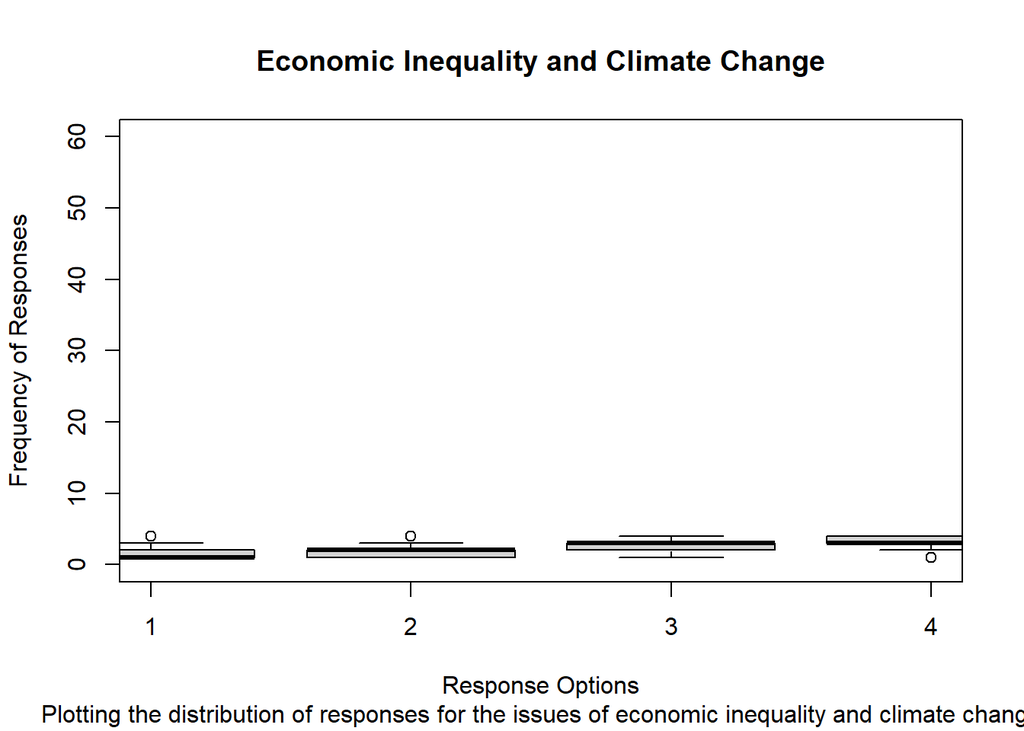

```r
plot(as.factor(USA_problems$climate_change), (USA_problems$economic_inequality),
     main = "Economic Inequality and Climate Change",
     sub = "Plotting the distribution of responses for the issues of economic inequality and climate change",
     xlab = "Response Options",
     ylab = "Frequency of Responses",
     xlim = c(1, 4),
     ylim = c(0, 60)
     )
```

That visualization is lacking. We can see somewhat of a distribution, but not clearly. Let’s try a correlation matrix. I want to see how the responses to each issue correlate to one another. For instance, if the respondent believes that economic inequality is a very big problem, do they also think that climate change is a very big problem?

First, I need to install a new package.

```r
library(corrplot)
```

Now, I’ll create a new dataframe containing the two variables I’m interested in.

```r
corrdf <- USA_problems[c(9:10)]
```

```r
corrdfnum <- as.data.frame(corrdf, 2, as.numeric)
sapply(corrdfnum, class)
```

```
##      economic_inequality climate_change
## [1,] "haven_labelled"    "haven_labelled"
## [2,] "vctrs_vctr"        "vctrs_vctr"
## [3,] "double"            "double"
```

Finally, I’ll create the correlation matrix.

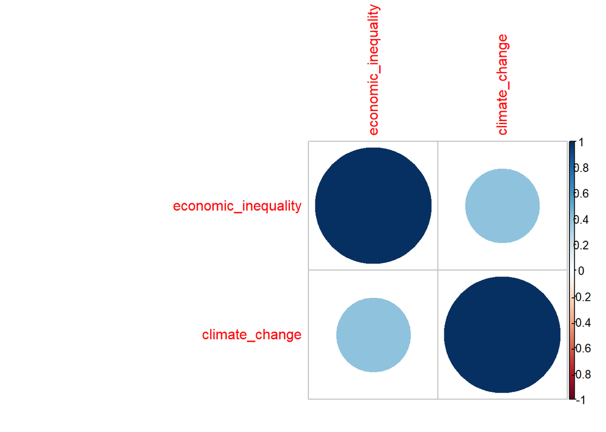

```r
C <- cor(corrdfnum, use = "pairwise.complete.obs")
corrplot (C, method = 'circle')
```

While the correlation matrix is underwhelming, we do see what respondents who believed climate change was a big problem also believed that economic inequality was a big problem. For this project, this is where I’ll leave it! Next time, I think I’ll see how these responses correlate with how well the respondents believed Trump did while in office!